# WeRateDogs tweeted dog breed analysis

Now let's look at our ratings. Here are our 20 top dogs:

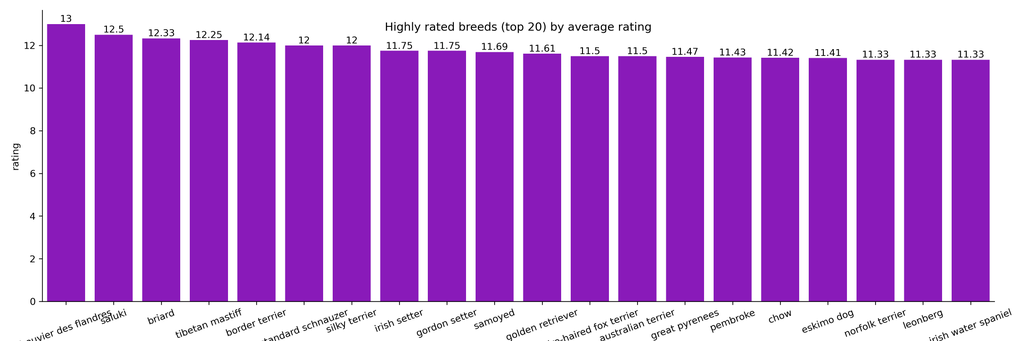

The rating of the dogs ranges from 13 to 11.3. The mean is 11.8 out of 10. The top rated breed is bouvier des flandres.  
As I can see, **golden retrievers** are still in the list, but some new breeds have appeared. Hmmm.  
Rating is a very subjective metric, let's look at the public opinion:

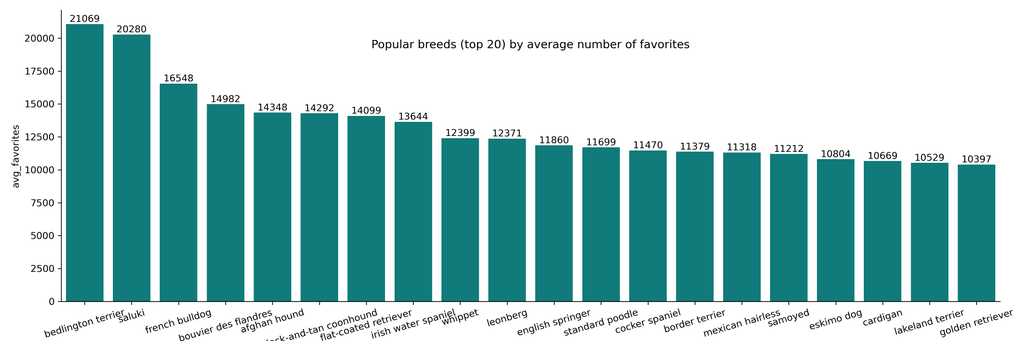

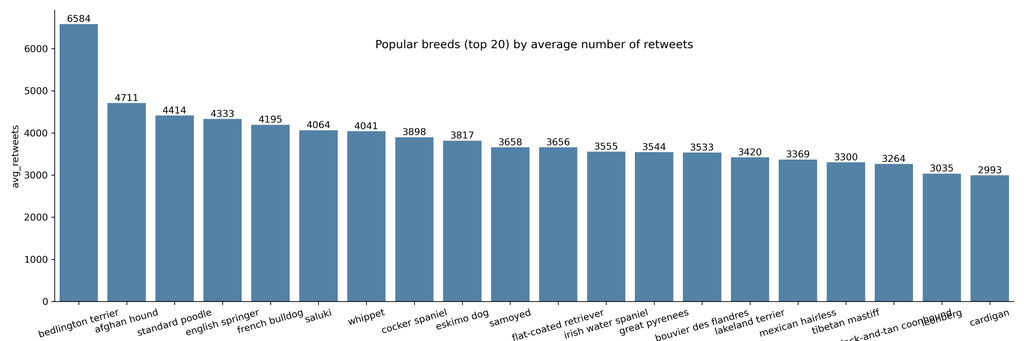

The dog breed with the most favourites (21069) is the bedlington terrier although it only has 6 tweets. The **golden retriever** with 151 tweets, but 10397 favourites is in 20th place. Average favourites per top 20 breeds is 13268.  
Guess what? The dog breed with the most retweets(6584) is the bedlington terrier as well, and the golden retriever did not get in the top 20. The cardigan breed has the least retweets(2993) out of the top 20 with 21 tweets. Average retweet number per breed is 3869.  
Favorites or retweets - the public love the same breeds.

Honestly, I don't know any of these breeds. The one thing for sure is that the **samoyed** and the **eskimo dog** are from the top 20 tweeted breeds and the **bouvier des flandres** from the bottom 20.

The last thing to look at is a dog breed distribution. As expected, many dog breeds have under 10 breed associates on WeRateDogs, the majority have under 30 tweets with occasional exceptions like **golden retrievers** (151), labrador retrievers (106), chihuahuas (90) and pembrokes (94).

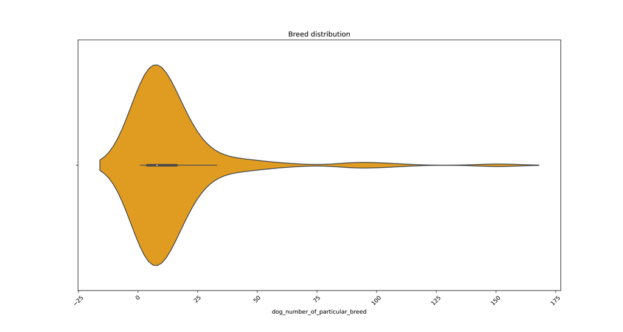

This is the end of my analysis. Hope you fond it interesting.

**Golden retriever** is the overall winner for me. What about yours?

[figure not shown]